# R Notebook

# CASO PRÁCTICO 1

1. Cargar el dataset como dataframe (el valor 999 es nulo) y mostrar sus primeras filas, su resumen estadístico y la estructura de sus columnas.

```r
# Cargar CSV
df <- read.csv('IBM.csv')

# Mostrar primeras filas
head(df)
```

|  | Date | Open | High | Low | Close | Volume | Adj.Close |
| --- | --- | --- | --- | --- | --- | --- | --- |
| 1 | 01/03/2000 | 102.00 | 105.50 | 100.06 | 100.25 | 10807800 | 84.48 |
| 2 | 02/03/2000 | 100.50 | 105.44 | 99.50 | 103.12 | 11192900 | 86.90 |
| 3 | 03/03/2000 | 107.25 | 110.00 | 106.06 | 108.00 | 10162800 | 91.01 |
| 4 | 06/03/2000 | 109.94 | 111.00 | 101.00 | 103.06 | 10747400 | 86.85 |
| 5 | 07/03/2000 | 106.00 | 107.00 | 101.69 | 103.00 | 10035100 | 86.80 |
| 6 | 08/03/2000 | 103.00 | 106.87 | 102.75 | 106.25 | 8376400 | 89.53 |

```r
# Resumen estadístico
summary(df)
```

```
     Date                Open             High             Low             Close            Volume           Adj.Close
 Length:3270        Min.   : 54.65   Min.   : 56.70   Min.   : 54.01   Min.   : 55.07   Min.   : 1027500   Min.   : 47.06
 Class :character   1st Qu.: 86.70   1st Qu.: 87.56   1st Qu.: 85.75   1st Qu.: 86.56   1st Qu.: 4772625   1st Qu.: 75.25
 Mode  :character   Median :104.06   Median :105.50   Median :102.50   Median :103.98   Median : 6201000   Median : 90.75
                    Mean   :117.74   Mean   :115.15   Mean   :112.93   Mean   :114.07   Mean   : 6998023   Mean   :103.72
                    3rd Qu.:126.72   3rd Qu.:127.56   3rd Qu.:125.39   3rd Qu.:126.59   3rd Qu.: 8337500   3rd Qu.:117.58
                    Max.   :999.00   Max.   :211.79   Max.   :210.06   Max.   :211.00   Max.   :41207300   Max.   :207.19
```

```r
# Estructura de Columnas
str(df)
```

```
'data.frame':   3270 obs. of  7 variables:
 $ Date     : chr  "01/03/2000" "02/03/2000" "03/03/2000" "06/03/2000" ...
 $ Open     : num  102 100 107 110 106 ...
 $ High     : num  106 105 110 111 107 ...
 $ Low      : num  100.1 99.5 106.1 101 101.7 ...
 $ Close    : num  100 103 108 103 103 ...
 $ Volume   : int  10807800 11192900 10162800 10747400 10035100 8376400 6334100 7093200 7871000 7973700 ...
 $ Adj.Close: num  84.5 86.9 91 86.8 86.8 ...
```

2. Reemplazar todos los valores nulos de la columna “Open” por su mediana.

```r
df$Open[which(is.na(df$Open))] <- median(df$Open, na.rm = T)
summary(df)
```

```
     Date                Open             High             Low             Close            Volume           Adj.Close
 Length:3270        Min.   : 54.65   Min.   : 56.70   Min.   : 54.01   Min.   : 55.07   Min.   : 1027500   Min.   : 47.06
 Class :character   1st Qu.: 86.70   1st Qu.: 87.56   1st Qu.: 85.75   1st Qu.: 86.56   1st Qu.: 4772625   1st Qu.: 75.25
 Mode  :character   Median :104.06   Median :105.50   Median :102.50   Median :103.98   Median : 6201000   Median : 90.75
                    Mean   :117.74   Mean   :115.15   Mean   :112.93   Mean   :114.07   Mean   : 6998023   Mean   :103.72
                    3rd Qu.:126.72   3rd Qu.:127.56   3rd Qu.:125.39   3rd Qu.:126.59   3rd Qu.: 8337500   3rd Qu.:117.58
                    Max.   :999.00   Max.   :211.79   Max.   :210.06   Max.   :211.00   Max.   :41207300   Max.   :207.19
```

3. Dividir la columna “Date” en “Día”, “Mes” y “Año”.

```r
df <- separate(df, Date, into = c("Día", "Mes", "Año"), sep=("/"))
head(df)
```

|  | Día | Mes | Año | Open | High | Low | Close | Volume | Adj.Close |
| --- | --- | --- | --- | --- | --- | --- | --- | --- | --- |
| 1 | 01 | 03 | 2000 | 102.00 | 105.50 | 100.06 | 100.25 | 10807800 | 84.48 |
| 2 | 02 | 03 | 2000 | 100.50 | 105.44 | 99.50 | 103.12 | 11192900 | 86.90 |
| 3 | 03 | 03 | 2000 | 107.25 | 110.00 | 106.06 | 108.00 | 10162800 | 91.01 |
| 4 | 06 | 03 | 2000 | 109.94 | 111.00 | 101.00 | 103.06 | 10747400 | 86.85 |
| 5 | 07 | 03 | 2000 | 106.00 | 107.00 | 101.69 | 103.00 | 10035100 | 86.80 |
| 6 | 08 | 03 | 2000 | 103.00 | 106.87 | 102.75 | 106.25 | 8376400 | 89.53 |

4. Cambiar la columna “Año” a factor.

```r
df$Año <- as.factor(df$Año)
head(df)
```

|  | Día | Mes | Año | Open | High | Low | Close | Volume | Adj.Close |
| --- | --- | --- | --- | --- | --- | --- | --- | --- | --- |
| 1 | 01 | 03 | 2000 | 102.00 | 105.50 | 100.06 | 100.25 | 10807800 | 84.48 |
| 2 | 02 | 03 | 2000 | 100.50 | 105.44 | 99.50 | 103.12 | 11192900 | 86.90 |
| 3 | 03 | 03 | 2000 | 107.25 | 110.00 | 106.06 | 108.00 | 10162800 | 91.01 |
| 4 | 06 | 03 | 2000 | 109.94 | 111.00 | 101.00 | 103.06 | 10747400 | 86.85 |
| 5 | 07 | 03 | 2000 | 106.00 | 107.00 | 101.69 | 103.00 | 10035100 | 86.80 |
| 6 | 08 | 03 | 2000 | 103.00 | 106.87 | 102.75 | 106.25 | 8376400 | 89.53 |

5. Devolver el precio más alto de cada año.

```r
df %>% select(Año, High) %>% group_by(Año) %>% summarise(max_año = max(High))
```

| Año | max_año |
| --- | --- |
| 2000 | 134.94 |
| 2001 | 124.70 |
| 2002 | 126.39 |
| 2003 | 94.54 |
| 2004 | 100.43 |
| 2005 | 99.10 |
| 2006 | 97.88 |
| 2007 | 121.46 |
| 2008 | 130.93 |
| 2009 | 132.85 |

[output cut: 4 more lines]

6. Mostrar una tabla de frecuencias para cada año.

```r
table(df$Año)
```

```
2000 2001 2002 2003 2004 2005 2006 2007 2008 2009 2010 2011 2012 2013
 212  248  252  252  252  252  251  251  253  252  252  252  250   41
```

7. Obtener una nueva columna que se llame “Diferencias” y que sea el resultado de restar al precio más alto el precio más bajo.

```r
df$Diferencias <- df$High - df$Low
head(df)
```

|  | Día | Mes | Año | Open | High | Low | Close | Volume | Adj.Close | Diferencias |
| --- | --- | --- | --- | --- | --- | --- | --- | --- | --- | --- |
| 1 | 01 | 03 | 2000 | 102.00 | 105.50 | 100.06 | 100.25 | 10807800 | 84.48 | 5.44 |
| 2 | 02 | 03 | 2000 | 100.50 | 105.44 | 99.50 | 103.12 | 11192900 | 86.90 | 5.94 |
| 3 | 03 | 03 | 2000 | 107.25 | 110.00 | 106.06 | 108.00 | 10162800 | 91.01 | 3.94 |
| 4 | 06 | 03 | 2000 | 109.94 | 111.00 | 101.00 | 103.06 | 10747400 | 86.85 | 10.00 |
| 5 | 07 | 03 | 2000 | 106.00 | 107.00 | 101.69 | 103.00 | 10035100 | 86.80 | 5.31 |
| 6 | 08 | 03 | 2000 | 103.00 | 106.87 | 102.75 | 106.25 | 8376400 | 89.53 | 4.12 |

8. Ordenar el dataset de forma ascendente por la columna “Diferencias”.

```r
df = df[order(df$Diferencias),]
head(df)
```

|  | Día | Mes | Año | Open | High | Low | Close | Volume | Adj.Close | Diferencias |
| --- | --- | --- | --- | --- | --- | --- | --- | --- | --- | --- |
| 1128 | 26 | 08 | 2004 | 85.00 | 85.04 | 84.69 | 84.69 | 3134400 | 73.48 | 0.35 |
| 1255 | 28 | 02 | 2005 | 92.53 | 92.76 | 92.41 | 92.58 | 4949800 | 80.63 | 0.35 |
| 1129 | 27 | 08 | 2004 | 84.65 | 84.95 | 84.59 | 84.94 | 2444800 | 73.70 | 0.36 |
| 2463 | 14 | 12 | 2009 | 129.65 | 129.98 | 129.60 | 129.93 | 5201300 | 121.60 | 0.38 |
| 1216 | 31 | 12 | 2004 | 98.60 | 98.91 | 98.49 | 98.58 | 2793200 | 85.70 | 0.42 |
| 1149 | 27 | 09 | 2004 | 84.10 | 84.44 | 83.98 | 84.16 | 4650300 | 73.02 | 0.46 |

9. Mostrar un resumen estadístico del dataset en función de los siguientes valores por cada año:
- Precio más alto de apertura.
- Precio más bajo de cierre.
- Media de la columna “Diferencia”.
- Número de elementos para cada año.

```r
df %>% select(Año, Open, Close, Diferencias) %>% group_by(Año) %>%
  summarise(
    max_open = max(Open),
    min_close = min(Close),
    mean_diff = mean(Diferencias),
    n_elements = n()
  )
```

| Año | max_open | min_close | mean_diff | n_elements |
| --- | --- | --- | --- | --- |
| 2000 | 999.00 | 81.56 | 4.143868 | 212 |
| 2001 | 999.00 | 84.81 | 3.105806 | 248 |
| 2002 | 125.00 | 55.07 | 2.513611 | 252 |
| 2003 | 93.90 | 75.18 | 1.558135 | 252 |
| 2004 | 999.00 | 82.21 | 1.212143 | 252 |
| 2005 | 98.97 | 72.01 | 1.186825 | 252 |
| 2006 | 999.00 | 73.57 | 1.123745 | 251 |
| 2007 | 999.00 | 90.90 | 1.849163 | 251 |
| 2008 | 129.83 | 71.74 | 3.317352 | 253 |
| 2009 | 132.41 | 81.98 | 2.174524 | 252 |

[output cut: 4 more lines]

10. Mostrar el sumatorio de la variable “Volumen” para todos los años.

```r
tapply(df$Volume, df$Año, sum)
```

```
      2000       2001       2002       2003       2004       2005       2006       2007       2008       2009       2010       2011       2012       2013
1524122700 2125060300 2347246300 1853423000 1316247600 1539128900 1455782200 2019185700 2377449700 2084230400 1618549600 1446186500 1021834200  155089000
```

11. Obtener dos histogramas para las variables de precio de apertura y cierre y rellenar los histogramas en función del año.

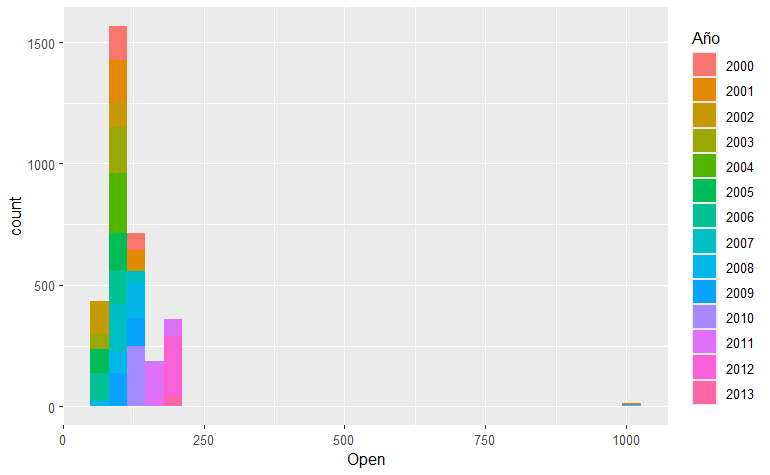

```r
# Apertura
ggplot(df) +
  geom_histogram(mapping = aes(x = Open, fill = Año))
```

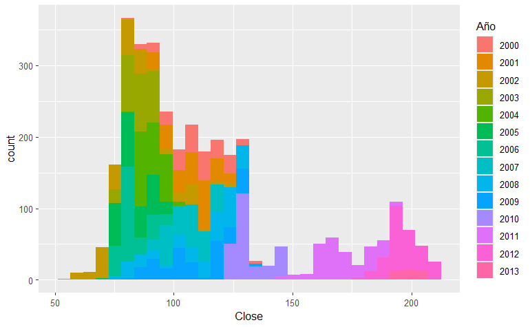

```r
# Cierre
ggplot(df) +
  geom_histogram(mapping = aes(x=Close, fill=Año))
```

12. Mostrar un diagrama de dispersión entre los precios más altos y bajos, además, muestra su recta de ajuste.

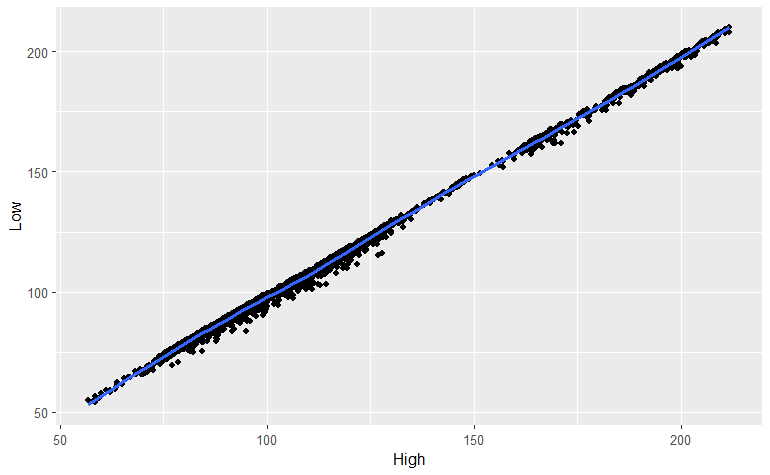

```r
ggplot(df) +
  geom_point(mapping = aes(High, Low)) +  geom_smooth(mapping = aes(High, Low))
```

13. Obtener un diagrama de caja y bigotes de la variable “Adj.Close” por año.

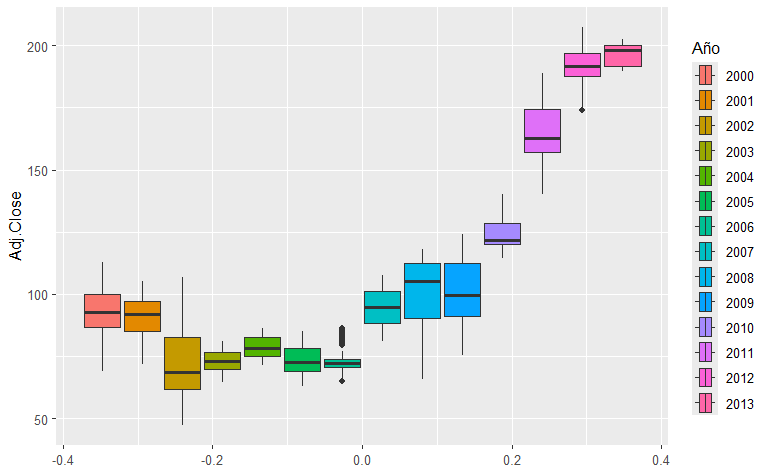

```r
ggplot(df) +
  geom_boxplot(mapping = aes(x = Adj.Close, fill = Año)) + coord_flip()
```

14. Mostrar para cada año un diagrama de densidad para la variable “Volume”.

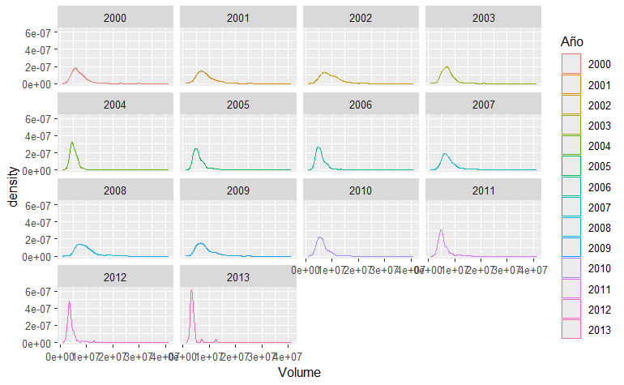

```r
ggplot(df) +
  geom_density(mapping = aes(Volume, colour = Año)) + facet_wrap(~Año)
```